# Simple Classification Model for Text Messages

David Lowe

March 7, 2018

# Introduction and Preliminary Inforamtion

Methodology Credit: Re-produced and adapted from a tutorial made available by Anish Singh Walia, Text Message Classification (https://datascienceplus.com/text-message-classification/).

Template Credit: Adapted from a template made available by Dr. Jason Brownlee of Machine Learning Mastery (http://machinelearningmastery.com/).

Data Set Description: https://www.kaggle.com/uciml/sms-spam-collection-dataset

Original Reference: http://www.dt.fee.unicamp.br/~tiago/smsspamcollection/

Modeling Approach: binary classification

The SMS Spam Collection is a set of SMS tagged messages that have been collected for SMS Spam research. It contains one set of SMS messages in English of 5,574 messages, tagged according being ham (legitimate) or spam.

Working through machine learning problems from end-to-end requires a structured modeling approach. Working problems through a project template can encourage you to think about the problem more critically, to challenge your assumptions, and to get good at all parts of a modeling project.

Any predictive modeling machine learning project can be broken down into about 6 common tasks:

1. Define Problem
2. Summarize Data (Use the word cloud visualization technique for this project)
3. Prepare Data (Not required for this project)
4. Evaluate Algorithms (Use Naive Bayes classifier and measure accuracy)
5. Improve Accuracy or Results
6. Finalize Model and Present Results

## 1. Prepare Problem

### 1.a) Load libraries

```r
library(quanteda)
```

```r
library(RColorBrewer)
library(ggplot2)
```

### 1.b) Load dataset

Data: https://www.kaggle.com/uciml/sms-spam-collection-dataset/downloads/spam.csv/1

```r
setwd("C:/Users/David/DEV/GitHub/r-classification-Text-Messages")
spam <- read.csv("kaggle_spam.csv",header=TRUE, sep=",", quote='\"\"', stringsAsFactors=FALSE)

# Add appropriate labels to the columns.
names(spam) <- c("type","message")
```

### 1.c) Split-out validation dataset

Create a training (variable name “.train”) and a test/validation (variable name “.test”) dataset

```r
seed_num <- 888
set.seed(seed_num)

# Randomly shuffle the dataset downloaded from Kaggle
spam <- spam[sample(nrow(spam)),]

# Split out the training and test/validation datasets
# create a list of 80% of the rows in the original dataset we can use for training
train_index <- round(nrow(spam)*0.80)
spam.train <- spam[1:train_index,]

# Select the remaining 20% of the data for testing and validation
spam.test <- spam[train_index:nrow(spam),]
```

## 2. Summarize Data

To gain a better understanding of the data that we have on-hand, we will leverage a number of descriptive statistics and data visualization techniques. The plan is to use the results to consider new questions, review assumptions, and validate hypotheses that we can investigate later with specialized models.

### 2.a) Descriptive statistics

#### 2.a.i) Dimensions of the dataset.

```r
dim(spam)
```

```
## [1] 5572    5
```

```r
dim(spam.train)
```

```
## [1] 4458    5
```

```r
dim(spam.test)
```

```
## [1] 1115    5
```

#### 2.a.ii) Distribution of the class attribute.

```r
table(spam$type)
```

```
##
##  ham spam
## 4825  747
```

#### 2.a.iii) Finally, a peek at the data itself.

```r
head(spam, n=10)
```

```
##      type
## 143   ham
## 1932  ham
## 342   ham
## 3808  ham
## 4273  ham
## 580   ham
## 2175  ham
## 1499  ham
## 272   ham
## 5018  ham
##                                                                                                                                                               message
## 143  A swt thought: \\Nver get tired of doing little things 4 lovable persons..\\" Coz..somtimes those little things occupy d biggest part in their Hearts.. Gud ni8"
## 1932                                                                                                                              What pa tell me.. I went to bath:-)
## 342           I take it the post has come then! You must have 1000s of texts now! Happy reading. My one from wiv hello caroline at the end is my favourite. Bless him
## 3808                                                                                                                            Mm you ask him to come its enough :-)
## 4273                                                       Kind of. Just missed train cos of asthma attack, nxt one in half hr so driving in. not sure where to park.
## 580                      Arngd marriage is while u r walkin unfortuntly a snake bites u. bt love marriage is dancing in frnt of d snake &amp; sayin Bite me, bite me.
## 2175                                                                                                                                    See? I thought it all through
## 1499       Time n Smile r the two crucial things in our life. Sometimes time makes us to forget smile, and sometimes someone's smile makes us to forget time gud noon
## 272               Night has ended for another day, morning has come in a special way. May you smile like the sunny rays and leaves your worries at the blue blue bay.
## 5018         Babe ! What are you doing ? Where are you ? Who are you talking to ? Do you think of me ? Are you being a good boy? Are you missing me? Do you love me ?
##      NA NA NA
## 143
## 1932
## 342
## 3808
## 4273
## 580
## 2175
## 1499
## 272
## 5018
```

### 2.b) Data visualizations

#### 2.b.i) Building the Word Clouds

Use Quanteda’s corpus() command to construct a corpus from the text field of our raw data. A corpus is a data structure that holds the documents (text messages in this case) and the text within the documents.

After the corpus is built, we will attach the label field as a document variable to the corpus using the docvars() command. We attach label as a variable directly to our corpus, so we can associate SMS messages with their respective ham/spam label later in the analysis.

```r
# Attach the class labels to the corpus message text
msg.corpus<-corpus(spam$message)
docvars(msg.corpus)<-spam$type
```

#### 2.b.ii) Plotting the Word Clouds

We will subset and filter all the spam text messages from the message corpus. Next, we will generate a document feature matrix (DFM) which is a sparse matrix consisting of the frequency of words that occur in a document. The rows in DFM represent the document. The columns represent the words/terms of the sentence in the document as well as the frequency of its appearance in the document.

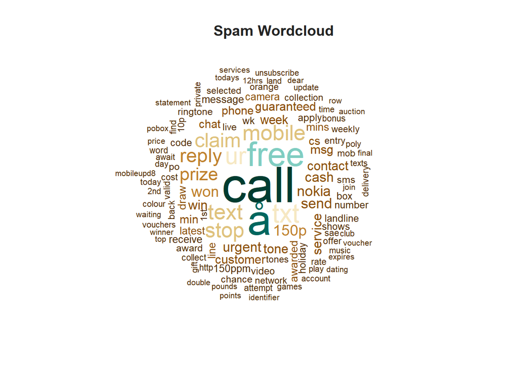

```r
# Subset only the spam messages
spam.plot<-corpus_subset(msg.corpus, docvar1=="spam")

# Create a DFM and Wordcloud
spam.plot<-dfm(spam.plot, tolower=TRUE, remove_punct=TRUE, remove_twitter=TRUE, remove_numbers=TRUE, remove=stopwords(source="smart"))
spam.col <- brewer.pal(10, "BrBG")
textplot_wordcloud(spam.plot, min_count=16, color=spam.col)
title("Spam Wordcloud", col.main = "grey14")
```

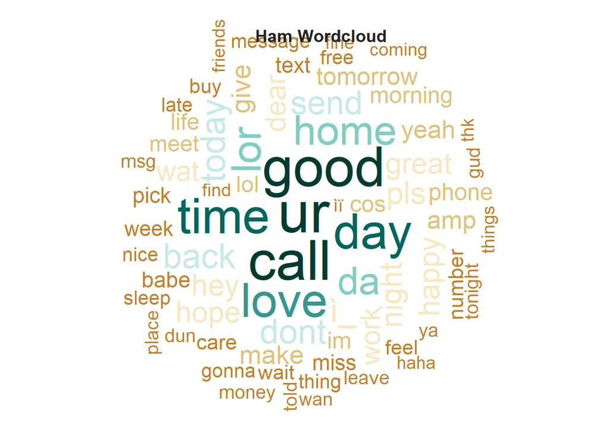

```r
# Subset only the ham messages
ham.plot<-corpus_subset(msg.corpus, docvar1=="ham")

# Create a DFM and Wordcloud
ham.plot<-dfm(ham.plot,tolower=TRUE, remove_punct=TRUE, remove_twitter=TRUE, remove_numbers=TRUE, remove=c("gt", "lt", stopwords(source = "smart")))
ham.col=brewer.pal(10, "BrBG")
textplot_wordcloud(ham.plot, min_count=50, color=ham.col)
title("Ham Wordcloud", col.main = "grey14")
```

#### 2.b.iii) Examine specific attributes for potential impact to the class attribute

```r
# Not applicable for this iteration of the project
```

## 3. Prepare Data

Some dataset may require additional preparation activities that will best exposes the structure of the problem and the relationships between the input attributes and the output variable. Some data-prep tasks might include:

- Cleaning data by removing duplicates, marking missing values and even imputing missing values.
- Feature selection where redundant features may be removed.
- Data transforms where attributes are scaled or redistributed in order to best expose the structure of the problem later to learning algorithms.

### 3.a) Data Cleaning

```r
# Not applicable for this iteration of the project
```

### 3.b) Feature Selection

```r
# Not applicable for this iteration of the project
```

### 3.c) Data Transforms

```r
# Not applicable for this iteration of the project
```

## 4. Evaluate Algorithms

After the data-prep, we next work on finding a workable model by evaluating a subset of machine learning algorithms that are good at exploiting the structure of the dataset. The typical evaluation tasks include:

- Defining test options such as cross validation and the evaluation metric to use.
- Spot checking a suite of linear and nonlinear machine learning algorithms.
- Comparing the estimated accuracy of algorithms.

### 4.a) Test options and evaluation metric

```r
# Not applicable for this iteration of the project
```

### 4.b) Spot Check Algorithms

```r
# Generate the document freq matrix
msg.dfm <- dfm(msg.corpus, tolower = TRUE)
msg.dfm <- dfm_trim(msg.dfm, min_count = 5, min_docfreq = 3)
msg.dfm <- dfm_tfidf(msg.dfm)
head(msg.dfm)
```

```
## Document-feature matrix of: 6 documents, 1,932 features (99% sparse).
```

```r
# Split the training and testing data of dfm
msg.dfm.train<-msg.dfm[1:train_index,]
msg.dfm.test<-msg.dfm[train_index:nrow(spam),]

# Train the predictive model with the Naive Bayes classifier
nb.classifier <- textmodel_nb(msg.dfm.train,spam.train[,1])
nb.classifier
```

```
##
## Call:
## textmodel_nb.dfm(x = msg.dfm.train, y = spam.train[, 1])
##
## Distribution: multinomial; prior: uniform; smoothing value: 1; 4458 training documents; 1932 fitted features.
```

### 4.c) Compare Algorithms

```r
# Not applicable for this iteration of the project
```

## 5. Improve Accuracy

After we achieve a short list of machine learning algorithms with good level of accuracy, we can leverage ways to improve the accuracy of the models:

- Search for a combination of parameters for each algorithm using caret that yields the best results.
- Combine the prediction of multiple models into an ensemble prediction using standalone algorithms or the caretEnsemble package.

### 5.a) Algorithm Tuning

```r
# Not applicable for this iteration of the project
```

### 5.b) Ensembles

```r
# Not applicable for this iteration of the project
```

## 6. Finalize Model

Once we have narrow down to a model that we believe can make accurate predictions on unseen data, we are ready to finalize it. Finalizing a model may involve sub-tasks such as:

- Using an optimal model tuned to make predictions on unseen data.
- Creating a standalone model using the tuned parameters
- Saving an optimal model to file for later use.

### 6.a) Predictions on validation dataset

```r
# Generate a confusion matrix
pred<-predict(nb.classifier,msg.dfm.test)

# Use pred$nb.predicted to extract the class labels
table(predicted=pred$nb.predicted,actual=spam.test[,1])
```

```
##          actual
## predicted ham spam
##      ham  950    8
##      spam  20  137
```

```r
# Display the acccuracy of the classifier on the test/validation data
mean(pred$nb.predicted==spam.test[,1])*100
```

```
## [1] 97.48879
```

### 6.b) Create standalone model on entire training dataset

```r
# Not applicable for this iteration of the project
```

### 6.c) Save model for later use

```r
# Not applicable for this iteration of the project
```